# Zadania_2

2026-03-18

## 2.1. Jednoduchá regresia

Urobme linearny regresny model a overme predpoklady.

```r
model <- lm(dist ~ speed, data = cars)
summary(model)
```

```
##
## Call:
## lm(formula = dist ~ speed, data = cars)
##
## Residuals:
##     Min      1Q  Median      3Q     Max
## -29.069  -9.525  -2.272   9.215  43.201
##
## Coefficients:
##             Estimate Std. Error t value Pr(>|t|)
## (Intercept) -17.5791     6.7584  -2.601   0.0123 *
## speed         3.9324     0.4155   9.464 1.49e-12 ***
## ---
## Signif. codes:  0 '***' 0.001 '**' 0.01 '*' 0.05 '.' 0.1 ' ' 1
##
## Residual standard error: 15.38 on 48 degrees of freedom
## Multiple R-squared:  0.6511, Adjusted R-squared:  0.6438
## F-statistic: 89.57 on 1 and 48 DF,  p-value: 1.49e-12
```

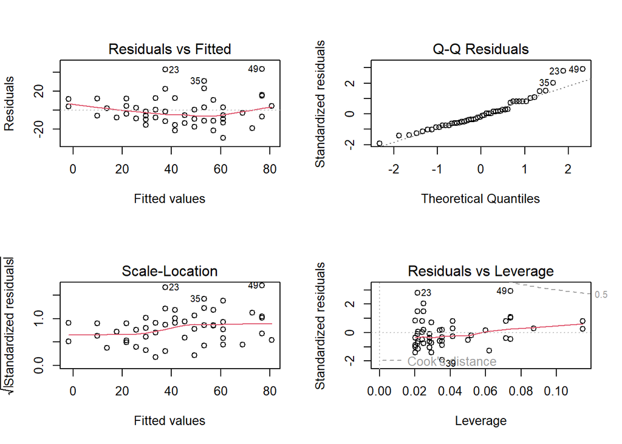

```r
# overenie predpokladov
par(mfrow = c(2, 2))
plot(model)
```

H0 - rychlost nema ziadny vplyv. beta=0.  
H1 - rychlost ma vyznamny vplyv. beta!= 0

Multiple R-squared: vysvetluje 65% toho, co sa dje s drahou.  
F statistika/riadok speed: p-value je ovela mensie ako 0.05 -> zamietame H0.  
Rychlost ma vplyv a pomaha predpovedat drahu  
Potom ked zvacsime o 1 jednotku rychlost, tak predlzime drahu o cca 4 jednotki.

*Ci splnene podmienky KLRM?* (linearita, normalnost chyb) Otestujeme statistiku. a vizualizujeme.

Na grafe 1 vidime mierne zakrivenie(vrece), tu nie je uplne linearny vztah. A na Q-Q nie vsetky body sleduju priamku, takze nie su chyby z normalneho rozdelenia. Graf Scale-Location ukazuje mierne stupajuci trend, co moze naznacovat heteroskedasticitu.

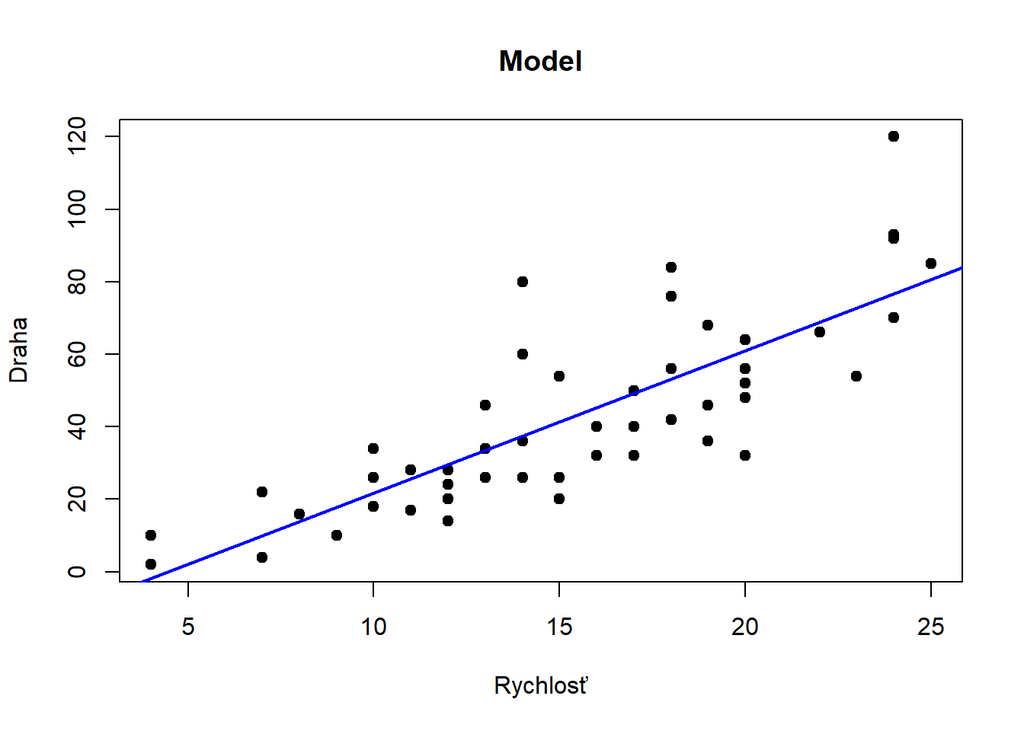

```r
predikcie <- predict(model)

# Nakreslime realne hodnoty a prelozime ich modelom
plot(cars$speed, cars$dist, main="Model",
     xlab="Rychlosť", ylab="Draha", pch=19)
abline(model, col="blue", lwd=2) # Toto je ta nasa vypocitana priamka
```

No, tu su nelinearne vztahy. Da sa najst nieco lepsie?

```r
# skusime model s druhou mocninou
model2 <- lm(dist ~ speed + I(speed^2), data = cars)
summary(model2)
```

```
##
## Call:
## lm(formula = dist ~ speed + I(speed^2), data = cars)
##
## Residuals:
##     Min      1Q  Median      3Q     Max
## -28.720  -9.184  -3.188   4.628  45.152
##
## Coefficients:
##             Estimate Std. Error t value Pr(>|t|)
## (Intercept)  2.47014   14.81716   0.167    0.868
## speed        0.91329    2.03422   0.449    0.656
## I(speed^2)   0.09996    0.06597   1.515    0.136
##
## Residual standard error: 15.18 on 47 degrees of freedom
## Multiple R-squared:  0.6673, Adjusted R-squared:  0.6532
## F-statistic: 47.14 on 2 and 47 DF,  p-value: 5.852e-12
```

## 2.2. Násobná regresia – generované dáta

Nájdite najvhodnejší lineárny regresný model. Overte predpoklady. Zdôvodnite prečo je model najvhodnejší. Testujte štatistickú významnosť modelu a parametrov.

```r
n <- 100
size <- rnorm(n, mean = 2000, sd = 500) # House size

bedrooms <- sample(2:5, n, replace = TRUE) # Number of bedrooms

bathrooms <- sample(1:4, n, replace = TRUE) # Number of bathrooms

age <- rpois(n, lambda = 10) # Age of the house

price <- 50000 + size * 150 + bedrooms * 10000 - age * 2000 + rnorm(n, mean = 0, sd =
30000) # Create target variable

house_data <- data.frame( Size = size, Bedrooms = bedrooms, Bathrooms =
bathrooms, Age = age, Price = price ) # Create data frame
```

```r
cor(house_data )#pozrieme sa na korelacne koeficienty
```

```
##                  Size    Bedrooms   Bathrooms         Age       Price
## Size       1.00000000 -0.03551523  0.04773860 -0.03899937  0.94462687
## Bedrooms  -0.03551523  1.00000000  0.07796534 -0.11772687  0.09325746
## Bathrooms  0.04773860  0.07796534  1.00000000 -0.05687264  0.01248697
## Age       -0.03899937 -0.11772687 -0.05687264  1.00000000 -0.11867042
## Price      0.94462687  0.09325746  0.01248697 -0.11867042  1.00000000
```

Price ma vysoky koeficient s size, ine koeficienty sa blizia k nule. Pouzijeme metodu *postupnej eliminacie*.

```r
#Model 1 - vsetky premenne
full_model <- lm(Price ~ Size + Bedrooms + Bathrooms + Age, data = house_data)
summary(full_model)
```

```
##
## Call:
## lm(formula = Price ~ Size + Bedrooms + Bathrooms + Age, data = house_data)
##
## Residuals:
##    Min     1Q Median     3Q    Max
## -80916 -16707   2143  16947  85761
##
## Coefficients:
##              Estimate Std. Error t value Pr(>|t|)
## (Intercept) 60752.741  16942.917   3.586 0.000533 ***
## Size          149.966      4.741  31.632  < 2e-16 ***
## Bedrooms     9319.345   2302.215   4.048 0.000105 ***
## Bathrooms   -3755.152   2438.050  -1.540 0.126829
## Age         -2013.486    868.912  -2.317 0.022638 *
## ---
## Signif. codes:  0 '***' 0.001 '**' 0.01 '*' 0.05 '.' 0.1 ' ' 1
##
## Residual standard error: 26190 on 95 degrees of freedom
## Multiple R-squared:  0.9151, Adjusted R-squared:  0.9115
## F-statistic: 255.9 on 4 and 95 DF,  p-value: < 2.2e-16
```

```r
#Finalny model
final_model <- lm(Price ~ Size + Bedrooms + Age, data = house_data)
summary(final_model)
```

```
##
## Call:
## lm(formula = Price ~ Size + Bedrooms + Age, data = house_data)
##
## Residuals:
##    Min     1Q Median     3Q    Max
## -87398 -16611   1444  17201  79719
##
## Coefficients:
##              Estimate Std. Error t value Pr(>|t|)
## (Intercept) 52553.620  16199.480   3.244 0.001621 **
## Size          149.610      4.769  31.371  < 2e-16 ***
## Bedrooms     9057.418   2312.277   3.917 0.000168 ***
## Age         -1951.827    874.171  -2.233 0.027887 *
## ---
## Signif. codes:  0 '***' 0.001 '**' 0.01 '*' 0.05 '.' 0.1 ' ' 1
##
## Residual standard error: 26380 on 96 degrees of freedom
## Multiple R-squared:  0.9129, Adjusted R-squared:  0.9102
## F-statistic: 335.6 on 3 and 96 DF,  p-value: < 2.2e-16
```

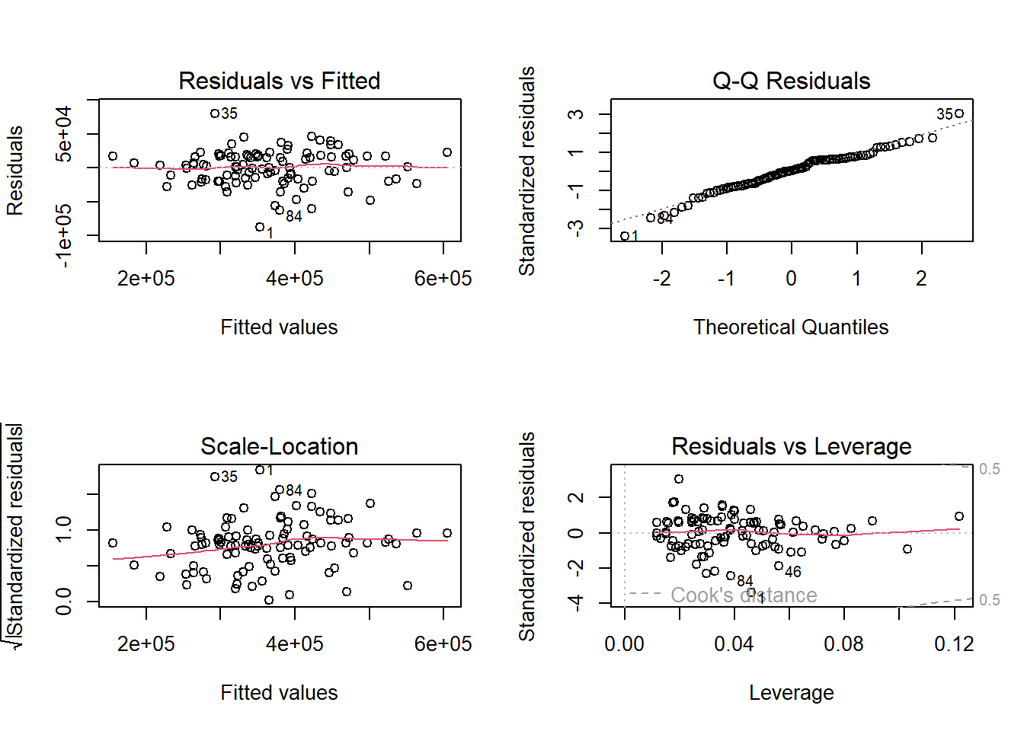

```r
#overenie predpokladov
par(mfrow = c(2, 2))
plot(final_model)
```

Pekne grafy. V prvom body rovnomerne okolo nuly, nevykazuje ziaden trend. Q-Q kopiruju priamku -> chyby maju normalne rozdelenie. Homoskedasticita: v scale-location rozdiel chyb je priblizne konstantny.

Asi mam dobry model.

## 2.3. Násobná regresia - dataset

Urobte lineárny regresný model pre premennú mpg z datasetu mtcars, pričom prediktormi budú premenné horsepower, weight a cylinders. Overte predpoklady pre tento model a otestujte jeho štatistickú významnosť. Vizualizujte vzťah reálnych a predikovaných hodnôt pre target. Dávajú iné premenné z datasetu ako prediktory lepší model a ak áno, tak ktoré?

```r
model_mtcars <- lm(mpg ~ hp + wt + cyl, data = mtcars)
summary(model_mtcars)
```

```
##
## Call:
## lm(formula = mpg ~ hp + wt + cyl, data = mtcars)
##
## Residuals:
##     Min      1Q  Median      3Q     Max
## -3.9290 -1.5598 -0.5311  1.1850  5.8986
##
## Coefficients:
##             Estimate Std. Error t value Pr(>|t|)
## (Intercept) 38.75179    1.78686  21.687  < 2e-16 ***
## hp          -0.01804    0.01188  -1.519 0.140015
## wt          -3.16697    0.74058  -4.276 0.000199 ***
## cyl         -0.94162    0.55092  -1.709 0.098480 .
## ---
## Signif. codes:  0 '***' 0.001 '**' 0.01 '*' 0.05 '.' 0.1 ' ' 1
##
## Residual standard error: 2.512 on 28 degrees of freedom
## Multiple R-squared:  0.8431, Adjusted R-squared:  0.8263
## F-statistic: 50.17 on 3 and 28 DF,  p-value: 2.184e-11
```

Statisticka vyznamnost: hp a cyl - p-honota nevyznamna, wh - ma velmi malu p-hodnotu, je vyznamna. To znamena, ze ak uz pozname vahu auta, informacia o vykone a valcoch nam k presnosti predpovede v tomto modeli uz takmer nic nepridava.  
Kazdych 1000 libier váhy navyse znízi spotrebu o cca 3.17 mpg.

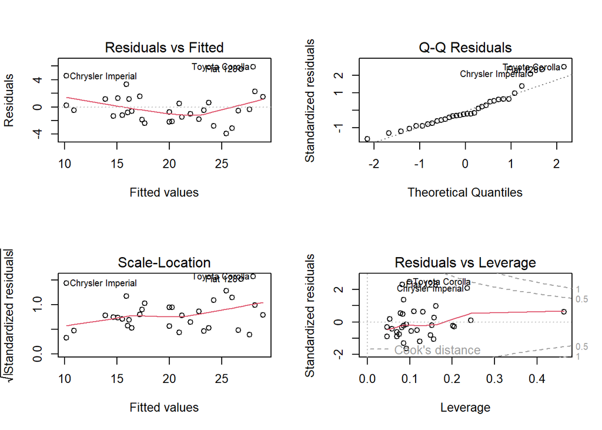

```r
par(mfrow = c(2, 2))
plot(model_mtcars)
```

Overenie predpokladov: Cervena ciara v prvom grafe nie je uplne rovna, Potom su viditelne outliery - tieto auta su extremne úsporne a model ich podcenuje. Predpoklad homoskedasticityje splnený. Model je v poriadku ale nie je dokonaly.

Potom vizualizacia:

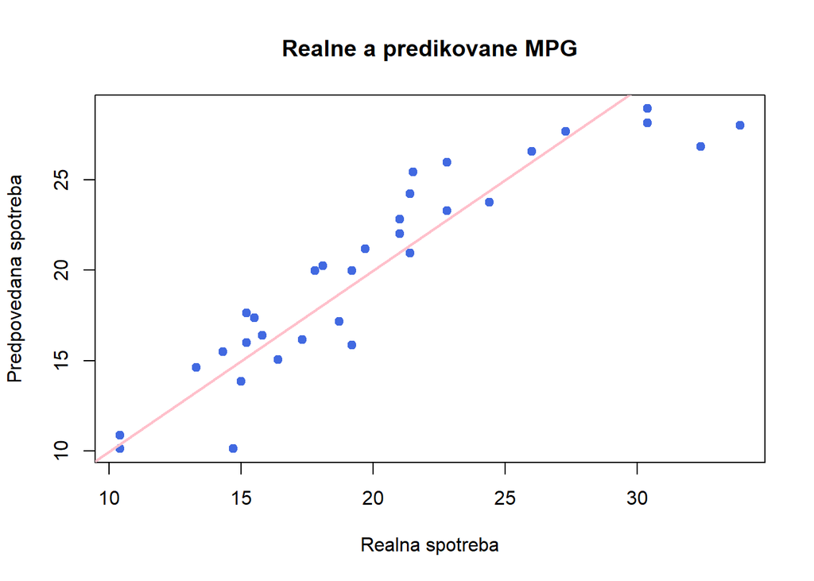

```r
predikcie <- predict(model_mtcars)

plot(mtcars$mpg, predikcie,
     main = "Realne a predikovane MPG",
     xlab = "Realna spotreba",
     ylab = "Predpovedana spotreba",
     pch = 19, col = "royalblue")
abline(0, 1, col = "pink", lwd = 2) # ciara idealnej predpovede
```

Da sa najst lepsi model?

```r
# Automaticke hladanie najlepsieho modelu
najlepsi_model <- step(lm(mpg ~ ., data = mtcars), direction = "both")
```

```
## Start:  AIC=70.9
## mpg ~ cyl + disp + hp + drat + wt + qsec + vs + am + gear + carb
##
##        Df Sum of Sq    RSS    AIC
## - cyl   1    0.0799 147.57 68.915
## - vs    1    0.1601 147.66 68.932
## - carb  1    0.4067 147.90 68.986
## - gear  1    1.3531 148.85 69.190
## - drat  1    1.6270 149.12 69.249
## - disp  1    3.9167 151.41 69.736
## - hp    1    6.8399 154.33 70.348
## - qsec  1    8.8641 156.36 70.765
## <none>              147.49 70.898
## - am    1   10.5467 158.04 71.108
## - wt    1   27.0144 174.51 74.280
##
## Step:  AIC=68.92
## mpg ~ disp + hp + drat + wt + qsec + vs + am + gear + carb
##
##        Df Sum of Sq    RSS    AIC
## - vs    1    0.2685 147.84 66.973
## - carb  1    0.5201 148.09 67.028
## - gear  1    1.8211 149.40 67.308
## - drat  1    1.9826 149.56 67.342
## - disp  1    3.9009 151.47 67.750
## - hp    1    7.3632 154.94 68.473
## <none>              147.57 68.915
## - qsec  1   10.0933 157.67 69.032
## - am    1   11.8359 159.41 69.384
## + cyl   1    0.0799 147.49 70.898
## - wt    1   27.0280 174.60 72.297
##
## Step:  AIC=66.97
## mpg ~ disp + hp + drat + wt + qsec + am + gear + carb
##
##        Df Sum of Sq    RSS    AIC
## - carb  1    0.6855 148.53 65.121
## - gear  1    2.1437 149.99 65.434
## - drat  1    2.2139 150.06 65.449
## - disp  1    3.6467 151.49 65.753
```

[output cut: 72 more lines]

```
## Step:  AIC=61.31
## mpg ~ wt + qsec + am
##
##        Df Sum of Sq    RSS    AIC
## <none>              169.29 61.307
## + hp    1     9.219 160.07 61.515
## + carb  1     8.036 161.25 61.751
## + disp  1     3.276 166.01 62.682
## + cyl   1     1.501 167.78 63.022
## + drat  1     1.400 167.89 63.042
## + gear  1     0.123 169.16 63.284
## + vs    1     0.000 169.29 63.307
## - am    1    26.178 195.46 63.908
## - qsec  1   109.034 278.32 75.217
## - wt    1   183.347 352.63 82.790
```

```r
summary(najlepsi_model)
```

```
##
## Call:
## lm(formula = mpg ~ wt + qsec + am, data = mtcars)
##
## Residuals:
##     Min      1Q  Median      3Q     Max
## -3.4811 -1.5555 -0.7257  1.4110  4.6610
##
## Coefficients:
##             Estimate Std. Error t value Pr(>|t|)
## (Intercept)   9.6178     6.9596   1.382 0.177915
## wt           -3.9165     0.7112  -5.507 6.95e-06 ***
## qsec          1.2259     0.2887   4.247 0.000216 ***
## am            2.9358     1.4109   2.081 0.046716 *
## ---
## Signif. codes:  0 '***' 0.001 '**' 0.01 '*' 0.05 '.' 0.1 ' ' 1
##
## Residual standard error: 2.459 on 28 degrees of freedom
## Multiple R-squared:  0.8497, Adjusted R-squared:  0.8336
## F-statistic: 52.75 on 3 and 28 DF,  p-value: 1.21e-11
```

V tomto modeli vsetky parametre su vyznamne a mame vyssiu presnost: Adjusted R-squared stupol z 0.826 na 0.833 Ak ma auto manualnu prevodovku (am = 1), prejde v priemere o 2.94 míle viac na galon ako automat.